```python
import pandas as pd
import numpy as np
import matplotlib.pyplot as plt
import seaborn as sns
from collections import Counter
```

# Visualizing Chipotle's Data

### Step 2. Import the dataset from this address.

### Step 3. Assign it to a variable called chipo.

```python
url = 'https://raw.githubusercontent.com/justmarkham/DAT8/master/data/chipotle.tsv'

chipo = pd.read_csv(url, sep = '\t')
```

### Step 4. See the first 10 entries

```python
chipo.head(10)
```

|  | order_id | quantity | item_name | choice_description | item_price |
| --- | --- | --- | --- | --- | --- |
| 0 | 1 | 1 | Chips and Fresh Tomato Salsa | NaN | $2.39 |
| 1 | 1 | 1 | Izze | [Clementine] | $3.39 |
| 2 | 1 | 1 | Nantucket Nectar | [Apple] | $3.39 |
| 3 | 1 | 1 | Chips and Tomatillo-Green Chili Salsa | NaN | $2.39 |
| 4 | 2 | 2 | Chicken Bowl | [Tomatillo-Red Chili Salsa (Hot), [Black Beans... | $16.98 |
| 5 | 3 | 1 | Chicken Bowl | [Fresh Tomato Salsa (Mild), [Rice, Cheese, Sou... | $10.98 |
| 6 | 3 | 1 | Side of Chips | NaN | $1.69 |
| 7 | 4 | 1 | Steak Burrito | [Tomatillo Red Chili Salsa, [Fajita Vegetables... | $11.75 |
| 8 | 4 | 1 | Steak Soft Tacos | [Tomatillo Green Chili Salsa, [Pinto Beans, Ch... | $9.25 |
| 9 | 5 | 1 | Steak Burrito | [Fresh Tomato Salsa, [Rice, Black Beans, Pinto... | $9.25 |

[figure not shown]

```python
chipo.plot(kind='bar')

plt.xlabel('Items')
plt.ylabel('Number of Times Ordered')
plt.title('Most ordered Chipotle\'s Items')

plt.show()
```

### Step 6. Create a scatterplot with the number of items

### orderered per order price

### Hint: Price should be in the X-axis and Items ordered in the Y-axis

```
(0.0, 36.7)
```

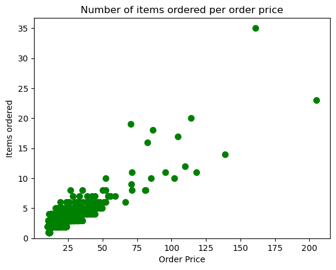

```python
chipo.item_price = [float(value[1:-1]) for value in chipo.item_price] # strip the dollar sign and trailing space

orders = chipo.groupby('order_id').sum()

plt.scatter(x = orders.item_price, y = orders.quantity, s = 50, c = 'green')

plt.xlabel('Order Price')
plt.ylabel('Items ordered')
plt.title('Number of items ordered per order price')
plt.ylim(0)
```

### Step 7. BONUS: Create a question and a graph to answer your

own question.

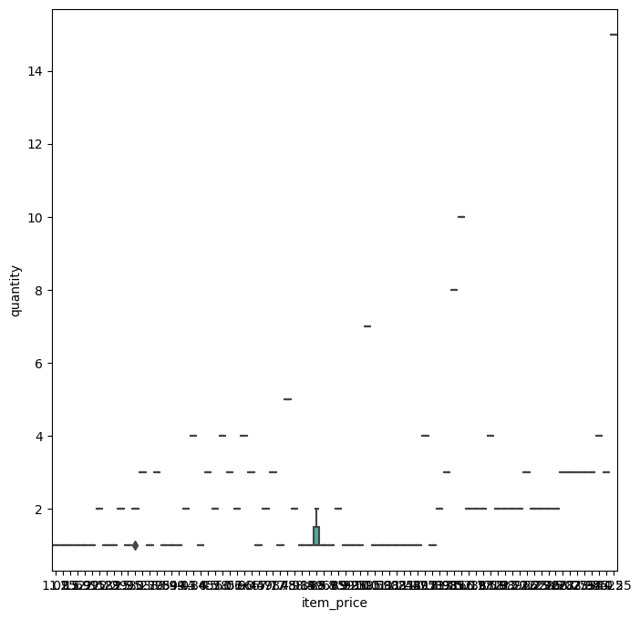

```python
plt.figure(figsize=(8, 8))
sns.boxplot(x = 'item_price', y = 'quantity', data=chipo)
```

# Online Retails Purchase

### Introduction:

#### Step 1. Import the necessary libraries

#### Step 2. Import the dataset from this address.

#### Step 3. Assign it to a variable called online_rt

#### Note: if you receive a utf-8 decode error, set encoding = 'latin1' in pd.read_csv() .

```python
path = 'https://raw.githubusercontent.com/guipsamora/pandas_exercises/master/07_Visualization/Online_Retail/Online_Retail.csv'

online_rt = pd.read_csv(path, encoding = 'latin1')

online_rt.head()
```

|  | InvoiceNo | StockCode | Description | Quantity | InvoiceDate | UnitPrice | CustomerID | Country |
| --- | --- | --- | --- | --- | --- | --- | --- | --- |
| 0 | 536365 | 85123A | WHITE HANGING HEART T-LIGHT HOLDER | 6 | 12/1/10 8:26 | 2.55 | 17850.0 | United Kingdom |
| 1 | 536365 | 71053 | WHITE METAL LANTERN | 6 | 12/1/10 8:26 | 3.39 | 17850.0 | United Kingdom |
| 2 | 536365 | 84406B | CREAM CUPID HEARTS COAT HANGER | 8 | 12/1/10 8:26 | 2.75 | 17850.0 | United Kingdom |
| 3 | 536365 | 84029G | KNITTED UNION FLAG HOT WATER BOTTLE | 6 | 12/1/10 8:26 | 3.39 | 17850.0 | United Kingdom |
| 4 | 536365 | 84029E | RED WOOLLY HOTTIE WHITE HEART. | 6 | 12/1/10 8:26 | 3.39 | 17850.0 | United Kingdom |

#### Step 4. Create a histogram with the 10 countries that have the

most 'Quantity' ordered except UK

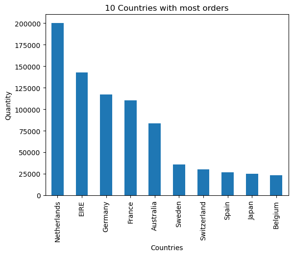

```python
countries = online_rt.groupby('Country').sum()

countries = countries.sort_values(by = 'Quantity',ascending = False)[1:11]

countries['Quantity'].plot(kind='bar')

plt.xlabel('Countries')
plt.ylabel('Quantity')
plt.title('10 Countries with most orders')

plt.show()
```

#### Step 5. Exclude negative Quantity entries

```python
online_rt = online_rt[online_rt.Quantity > 0]
online_rt.head()
```

|  | InvoiceNo | StockCode | Description | Quantity | InvoiceDate | UnitPrice | CustomerID | Country |
| --- | --- | --- | --- | --- | --- | --- | --- | --- |
| 0 | 536365 | 85123A | WHITE HANGING HEART T-LIGHT HOLDER | 6 | 12/1/10 8:26 | 2.55 | 17850.0 | United Kingdom |
| 1 | 536365 | 71053 | WHITE METAL LANTERN | 6 | 12/1/10 8:26 | 3.39 | 17850.0 | United Kingdom |
| 2 | 536365 | 84406B | CREAM CUPID HEARTS COAT HANGER | 8 | 12/1/10 8:26 | 2.75 | 17850.0 | United Kingdom |
| 3 | 536365 | 84029G | KNITTED UNION FLAG HOT WATER BOTTLE | 6 | 12/1/10 8:26 | 3.39 | 17850.0 | United Kingdom |
| 4 | 536365 | 84029E | RED WOOLLY HOTTIE WHITE HEART. | 6 | 12/1/10 8:26 | 3.39 | 17850.0 | United Kingdom |

#### Step 6. Create a scatterplot with the Quantity per UnitPrice by

CustomerID for the top 3 Countries (except UK)

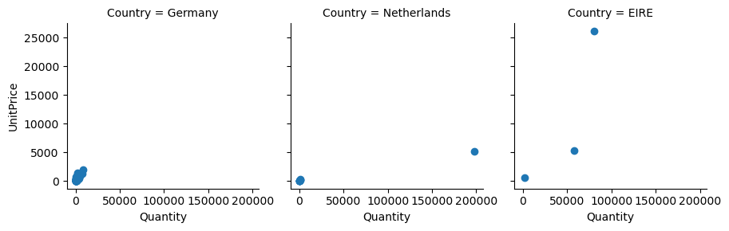

```python
customers = online_rt.groupby(['CustomerID','Country']).sum()
customers = customers[customers.UnitPrice > 0]

customers['Country'] = customers.index.get_level_values(1)

top_countries =  ['Netherlands', 'EIRE', 'Germany']

customers = customers[customers['Country'].isin(top_countries)]


g = sns.FacetGrid(customers, col="Country")

g.map(plt.scatter, "Quantity", "UnitPrice", alpha=1)

g.add_legend()
```

### Step 7. Investigate why the previous results look so

uninformative. This section might seem a bit tedious to go through. But I've thought of it as some kind of a simulation of problems one might encounter when dealing with data and other people. Besides there is a prize at the end (i.e. Section 8). (But feel free to jump right ahead into Section 8 if you want; it doesn't require that you finish this section.) Step 7.1 Look at the first line of code in Step 6. And try to figure out if it leads to any kind of problem.

#### Step 7.1.1 Display the first few rows of that DataFrame.

```python
customers = online_rt.groupby(['CustomerID','Country']).sum().head()

customers
```

| CustomerID | Country | Quantity | UnitPrice |
| --- | --- | --- | --- |
| 12346.0 | United Kingdom | 74215 | 1.04 |
| 12347.0 | Iceland | 2458 | 481.21 |
| 12348.0 | Finland | 2341 | 178.71 |
| 12349.0 | Italy | 631 | 605.10 |
| 12350.0 | Norway | 197 | 65.30 |

#### Step 7.1.2 Think about what that piece of code does and display the dtype of UnitPrice

```python
customers.UnitPrice.dtype
```

```
dtype('float64')
```

#### Step 7.1.3 Pull data from online_rt for CustomerID s 12346.0 and 12347.0.

```python
display(online_rt[online_rt.CustomerID == 12347.0].
        sort_values(by='UnitPrice', ascending = False).head())
display(online_rt[online_rt.CustomerID == 12346.0].
        sort_values(by='UnitPrice', ascending = False).head())
```

|  | InvoiceNo | StockCode | Description | Quantity | InvoiceDate | UnitPrice | CustomerID | Country |
| --- | --- | --- | --- | --- | --- | --- | --- | --- |
| 428966 | 573511 | 22423 | REGENCY CAKESTAND 3 TIER | 6 | 10/31/11 12:25 | 12.75 | 12347.0 | Iceland |
| 286637 | 562032 | 22423 | REGENCY CAKESTAND 3 TIER | 3 | 8/2/11 8:48 | 12.75 | 12347.0 | Iceland |
| 72267 | 542237 | 22423 | REGENCY CAKESTAND 3 TIER | 3 | 1/26/11 14:30 | 12.75 | 12347.0 | Iceland |
| 148300 | 549222 | 22423 | REGENCY CAKESTAND 3 TIER | 3 | 4/7/11 10:43 | 12.75 | 12347.0 | Iceland |
| 428967 | 573511 | 23173 | REGENCY TEAPOT ROSES | 2 | 10/31/11 12:25 | 9.95 | 12347.0 | Iceland |

|  | InvoiceNo | StockCode | Description | Quantity | InvoiceDate | UnitPrice | CustomerID | Country |
| --- | --- | --- | --- | --- | --- | --- | --- | --- |
| 61619 | 541431 | 23166 | MEDIUM CERAMIC TOP STORAGE JAR | 74215 | 1/18/11 10:01 | 1.04 | 12346.0 | United Kingdom |

#### Step 7.2 Reinterpreting the initial problem.

To reiterate the question that we were dealing with: "Create a scatterplot with the Quantity per UnitPrice by CustomerID for the top 3 Countries" The question is open to a set of different interpretations. We need to disambiguate. We could do a single plot by looking at all the data from the top 3 countries. Or we could do one plot per country. To keep things consistent with the rest of the exercise, let's stick to the latter oprion. So that's settled. But "top 3 countries" with respect to what? Two answers suggest themselves: Total sales volume (i.e. total quantity sold) or total sales (i.e. revenue). This exercise goes for sales volume, so let's stick to that.

#### Step 7.2.1 Find out the top 3 countries in terms of sales volume.

```python
sales_volume = online_rt.groupby('Country').Quantity.sum().sort_values(ascending=False)

top3 = sales_volume.index[1:4]
top3
```

```
Index(['Netherlands', 'EIRE', 'Germany'], dtype='object', name='Country')
```

#### Step 7.2.2

Now that we have the top 3 countries, we can focus on the rest of the problem: "Quantity per UnitPrice by CustomerID". We need to unpack that. "by CustomerID" part is easy. That means we're going to be plotting one dot per CustomerID's on our plot. In other words, we're going to be grouping by CustomerID. "Quantity per UnitPrice" is trickier. Here's what we know: One axis will represent a Quantity assigned to a given customer. This is easy; we can just plot the total Quantity for each customer. The other axis will represent a UnitPrice assigned to a given customer. Remember a single customer can have any number of orders with different prices, so summing up prices isn't quite helpful. Besides it's not quite clear what we mean when we say "unit price per customer"; it sounds like price of the customer! A reasonable alternative is that we assign each customer the average amount each has paid per item. So let's settle that question in that manner.

#### Step 7.3 Modify, select and plot data

#### Step 7.3.1 Add a column to online_rt called Revenue calculate the revenue (Quantity *

UnitPrice) from each sale. We will use this later to figure out an average price per customer.

```python
online_rt['Revenue'] = online_rt.Quantity * online_rt.UnitPrice
online_rt.head()
```

|  | InvoiceNo | StockCode | Description | Quantity | InvoiceDate | UnitPrice | CustomerID | Country | Revenue |
| --- | --- | --- | --- | --- | --- | --- | --- | --- | --- |
| 0 | 536365 | 85123A | WHITE HANGING HEART T-LIGHT HOLDER | 6 | 12/1/10 8:26 | 2.55 | 17850.0 | United Kingdom | 15.30 |
| 1 | 536365 | 71053 | WHITE METAL LANTERN | 6 | 12/1/10 8:26 | 3.39 | 17850.0 | United Kingdom | 20.34 |
| 2 | 536365 | 84406B | CREAM CUPID HEARTS COAT HANGER | 8 | 12/1/10 8:26 | 2.75 | 17850.0 | United Kingdom | 22.00 |
| 3 | 536365 | 84029G | KNITTED UNION FLAG HOT WATER BOTTLE | 6 | 12/1/10 8:26 | 3.39 | 17850.0 | United Kingdom | 20.34 |
| 4 | 536365 | 84029E | RED WOOLLY HOTTIE WHITE HEART. | 6 | 12/1/10 8:26 | 3.39 | 17850.0 | United Kingdom | 20.34 |

#### Step 7.3.2 Group by CustomerID and Country and find out the average price

( AvgPrice ) each customer spends per unit.

```python
grouped = online_rt[online_rt.Country.isin(top3)].groupby(['CustomerID','Country'])

plottable = grouped['Quantity','Revenue'].agg('sum')
plottable['AvgPrice'] = plottable.Revenue / plottable.Quantity


plottable['Country'] = plottable.index.get_level_values(1)
plottable.head()
```

| CustomerID | Country | Quantity | Revenue | AvgPrice | Country |
| --- | --- | --- | --- | --- | --- |
| 12426.0 | Germany | 258 | 582.73 | 2.258643 | Germany |
| 12427.0 | Germany | 533 | 825.80 | 1.549343 | Germany |
| 12468.0 | Germany | 366 | 729.54 | 1.993279 | Germany |
| 12471.0 | Germany | 8212 | 19824.05 | 2.414034 | Germany |
| 12472.0 | Germany | 4148 | 6572.11 | 1.584405 | Germany |

#### Step 7.3.3 Plot

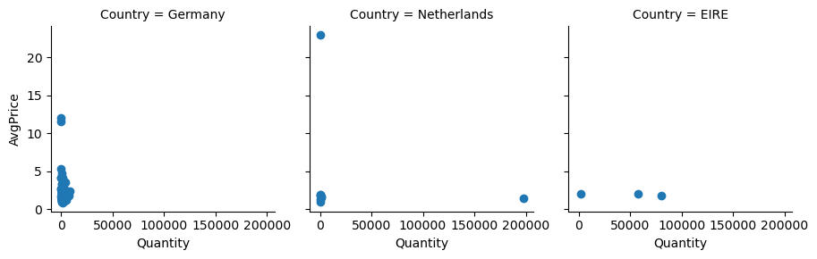

```python
g = sns.FacetGrid(plottable, col="Country")

g.map(plt.scatter, "Quantity", "AvgPrice", alpha=1)

g.add_legend();
```

#### Step 7.4 What to do now?

We aren't much better-off than what we started with. The data are still extremely scattered around and don't seem quite informative. But we shouldn't despair! There are two things to realize: 1) The data seem to be skewed towaards the axes (e.g. we don't have any values where Quantity = 50000 and AvgPrice = 5). So that might suggest a trend. 2) We have more data! We've only been looking at the data from 3 different countries and they are plotted on different graphs. So: we should plot the data regardless of Country and hopefully see a less scattered graph.

#### Step 7.4.1 Plot the data for each CustomerID on a single graph

```
[]
```

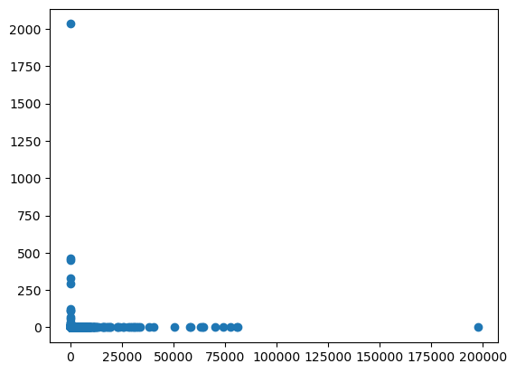

```python
grouped = online_rt.groupby(['CustomerID'])
plottable = grouped['Quantity','Revenue'].agg('sum')
plottable['AvgPrice'] = plottable.Revenue / plottable.Quantity

plt.scatter(plottable.Quantity, plottable.AvgPrice)
plt.plot()
```

#### Step 7.4.2 Zoom in so we can see that curve more clearly

```
[]
```

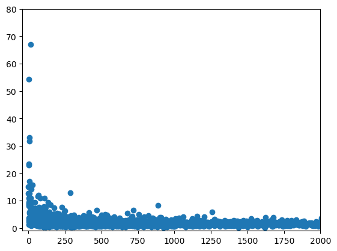

```python
grouped = online_rt.groupby(['CustomerID','Country'])
plottable = grouped.agg({'Quantity': 'sum',
                         'Revenue': 'sum'})
plottable['AvgPrice'] = plottable.Revenue / plottable.Quantity


plt.scatter(plottable.Quantity, plottable.AvgPrice)

plt.xlim(-40,2000)
plt.ylim(-1,80)

plt.plot()
```

#### 8. Plot a line chart showing revenue (y) per UnitPrice (x).

Did Step 7 give us any insights about the data? Sure! As average price increases, the quantity ordered decreses. But that's hardly surprising. It would be surprising if that wasn't the case! Nevertheless the rate of drop in quantity is so drastic, it makes me wonder how our revenue changes with respect to item price. It would not be that surprising if it didn't change that much. But it would be interesting to know whether most of our revenue comes from expensive or inexpensive items, and how that relation looks like. That is what we are going to do now.

#### 8.1 Group UnitPrice by intervals of 1 for prices [0,50), and sum

Quantity and Revenue .

```python
price_start = 0
price_end = 50
price_interval = 1

buckets = np.arange(price_start,price_end,price_interval)

revenue_per_price = online_rt.groupby(pd.cut(online_rt.UnitPrice, buckets)).Revenue.sum()
revenue_per_price.head()
```

```
UnitPrice
(0, 1]    1107774.544
(1, 2]    2691765.110
(2, 3]    2024143.090
(3, 4]     865101.780
(4, 5]    1219377.050
Name: Revenue, dtype: float64
```

#### 8.3 Plot.

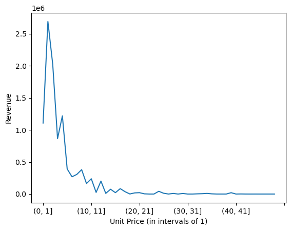

```python
revenue_per_price.plot()
plt.xlabel('Unit Price (in intervals of '+str(price_interval)+')')
plt.ylabel('Revenue')
plt.show()
```

#### 8.4 Make it look nicer.

x-axis needs values. y-axis isn't that easy to read; show in terms of millions.

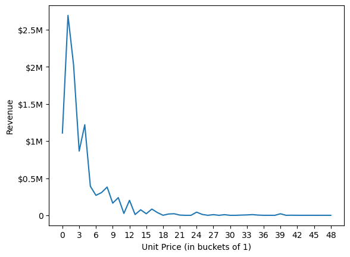

```python
revenue_per_price.plot()

plt.xlabel('Unit Price (in buckets of '+str(price_interval)+')')
plt.ylabel('Revenue')

plt.xticks(np.arange(price_start,price_end,3),
           np.arange(price_start,price_end,3))
plt.yticks([0, 500000, 1000000, 1500000, 2000000, 2500000],
           ['0', '$0.5M', '$1M', '$1.5M', '$2M', '$2.5M'])
plt.show()
```

#### BONUS: Create your own question and answer it.

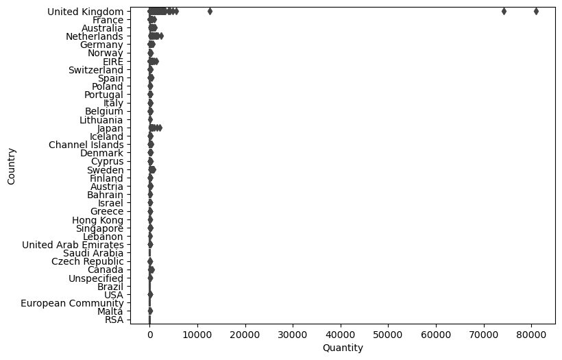

```python
plt.figure(figsize=(8, 6))
sns.boxplot(x = 'Quantity', y = 'Country', data=online_rt)
```

# Scores

#### Step 1. Import the necessary libraries

#### Step 2. Create the DataFrame that should look like the one

below.

```python
raw_data = {'first_name': ['Jason', 'Molly', 'Tina', 'Jake', 'Amy'],
            'last_name': ['Miller', 'Jacobson', 'Ali', 'Milner', 'Cooze'],
            'female': [0, 1, 1, 0, 1],
            'age': [42, 52, 36, 24, 73],
            'preTestScore': [4, 24, 31, 2, 3],
            'postTestScore': [25, 94, 57, 62, 70]}

df = pd.DataFrame(raw_data, columns = ['first_name', 'last_name', 'age', 'female', 'preTestScore', 'postTestScore'])

df
```

|  | first_name | last_name | age | female | preTestScore | postTestScore |
| --- | --- | --- | --- | --- | --- | --- |
| 0 | Jason | Miller | 42 | 0 | 4 | 25 |
| 1 | Molly | Jacobson | 52 | 1 | 24 | 94 |
| 2 | Tina | Ali | 36 | 1 | 31 | 57 |
| 3 | Jake | Milner | 24 | 0 | 2 | 62 |
| 4 | Amy | Cooze | 73 | 1 | 3 | 70 |

#### Step 3. Create a Scatterplot of preTestScore and

postTestScore, with the size of each point determined by age Hint: Don't forget to place the labels

[figure not shown]

```python
plt.scatter(df.preTestScore, df.postTestScore, s=df.age)

plt.title("preTestScore x postTestScore")
plt.xlabel('preTestScore')
plt.ylabel('preTestScore')
```

#### Step 4. Create a Scatterplot of preTestScore and

postTestScore. This time the size should be 4.5 times the postTestScore and the color determined by sex

[figure not shown]

```python
plt.scatter(df.preTestScore, df.postTestScore, s= df.postTestScore * 4.5, c = df.female)

plt.title("preTestScore x postTestScore")
plt.xlabel('preTestScore')
plt.ylabel('preTestScore')
```

#### BONUS: Create your own question and answer it.

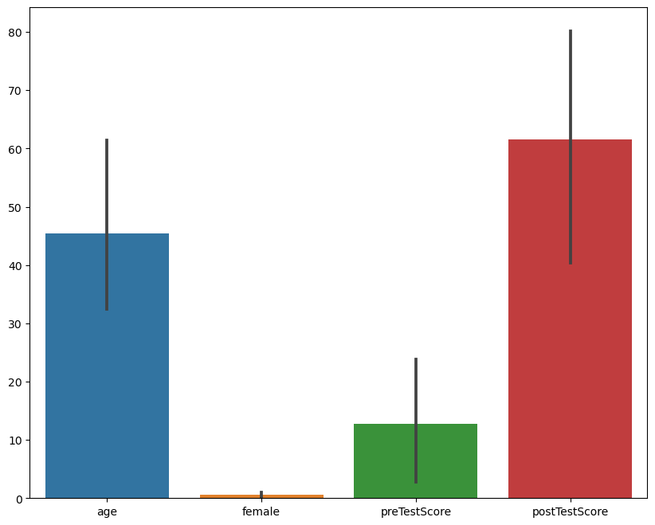

```python
plt.figure(figsize=(10,8))
sns.barplot(data=df)
```

# Tips

Introduction: This exercise was created based on the tutorial and documentation from Seaborn The dataset being used is tips from Seaborn.

#### Step 1. Import the necessary libraries:

#### Step 2. Import the dataset from this address.

#### Step 3. Assign it to a variable called tips

```python
url = 'https://raw.githubusercontent.com/guipsamora/pandas_exercises/master/07_Visualization/Tips/tips.csv'
tips = pd.read_csv(url)

tips.head()
```

|  | Unnamed: 0 | total_bill | tip | sex | smoker | day | time | size |
| --- | --- | --- | --- | --- | --- | --- | --- | --- |
| 0 | 0 | 16.99 | 1.01 | Female | No | Sun | Dinner | 2 |
| 1 | 1 | 10.34 | 1.66 | Male | No | Sun | Dinner | 3 |
| 2 | 2 | 21.01 | 3.50 | Male | No | Sun | Dinner | 3 |
| 3 | 3 | 23.68 | 3.31 | Male | No | Sun | Dinner | 2 |
| 4 | 4 | 24.59 | 3.61 | Female | No | Sun | Dinner | 4 |

#### Step 4. Delete the Unnamed 0 column

```python
del tips['Unnamed: 0']

tips.head()
```

|  | total_bill | tip | sex | smoker | day | time | size |
| --- | --- | --- | --- | --- | --- | --- | --- |
| 0 | 16.99 | 1.01 | Female | No | Sun | Dinner | 2 |
| 1 | 10.34 | 1.66 | Male | No | Sun | Dinner | 3 |
| 2 | 21.01 | 3.50 | Male | No | Sun | Dinner | 3 |
| 3 | 23.68 | 3.31 | Male | No | Sun | Dinner | 2 |
| 4 | 24.59 | 3.61 | Female | No | Sun | Dinner | 4 |

#### Step 5. Plot the total_bill column histogram

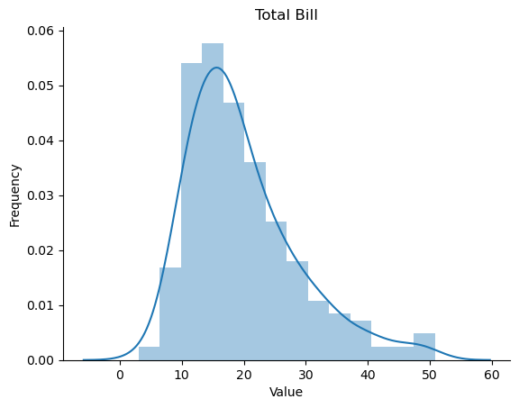

```python
ttbill = sns.distplot(tips.total_bill);

ttbill.set(xlabel = 'Value', ylabel = 'Frequency', title = "Total Bill")

sns.despine()
```

#### Step 6. Create a scatter plot presenting the relationship

between total_bill and tip

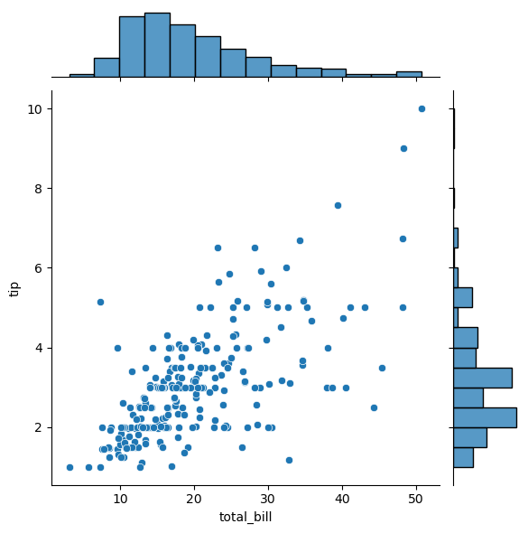

```python
sns.jointplot(x ="total_bill", y ="tip", data = tips)
```

#### Step 7. Create one image with the relationship of total_bill, tip

and size. Hint: It is just one function.

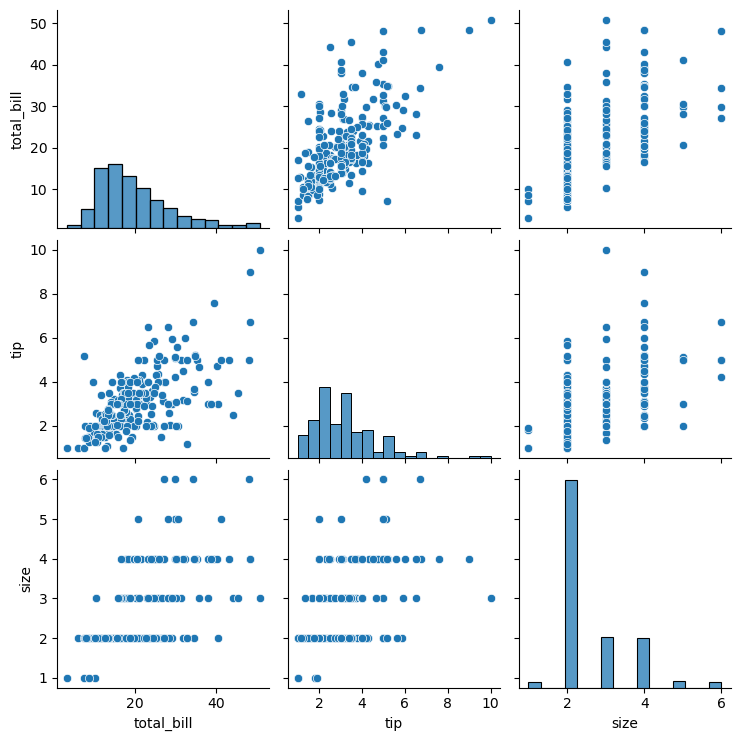

```python
sns.pairplot(tips)
```

#### Step 8. Present the relationship between days and total_bill

value

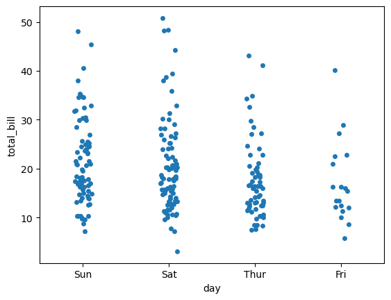

```python
sns.stripplot(x = "day", y = "total_bill", data = tips, jitter = True);
```

#### Step 9. Create a scatter plot with the day as the y-axis and tip

as the x-axis, differ the dots by sex

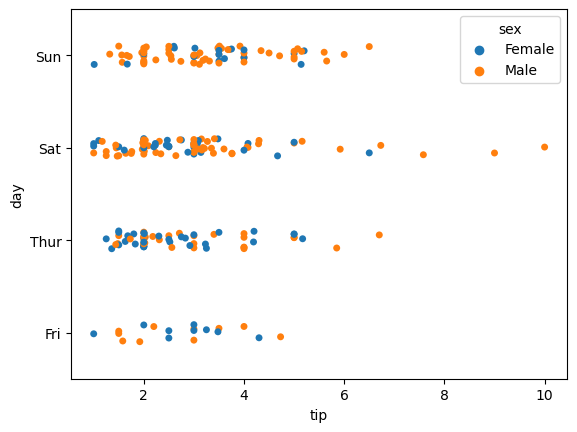

```python
sns.stripplot(x = "tip", y = "day", hue = "sex", data = tips, jitter = True);
```

#### Step 10. Create a box plot presenting the total_bill per day

differetiation the time (Dinner or Lunch)

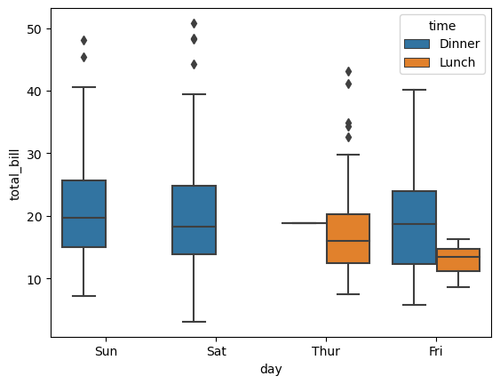

```python
sns.boxplot(x = "day", y = "total_bill", hue = "time", data = tips);
```

#### Step 11. Create two histograms of the tip value based for

Dinner and Lunch. They must be side by side.

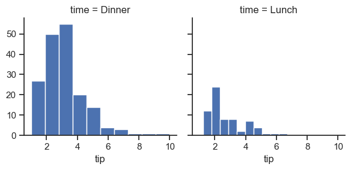

```python
sns.set(style = "ticks")

g = sns.FacetGrid(tips, col = "time")
g.map(plt.hist, "tip");
```

#### Step 12. Create two scatterplots graphs, one for Male and

another for Female, presenting the total_bill value and tip relationship, differing by smoker or no smoker They must be side by side.

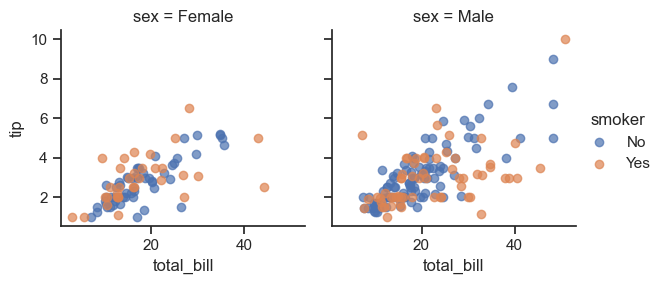

```python
g = sns.FacetGrid(tips, col = "sex", hue = "smoker")
g.map(plt.scatter, "total_bill", "tip", alpha =.7)

g.add_legend();
```

# Visualizing the Titanic Disaster

Introduction: This exercise is based on the titanic Disaster dataset avaiable at Kaggle. To know more about the variables check here

#### Step 1. Import the necessary libraries

#### Step 2. Import the dataset from this address

#### Step 3. Assign it to a variable titanic

```python
url = 'https://raw.githubusercontent.com/guipsamora/pandas_exercises/master/07_Visualization/Titanic_Desaster/train.csv'

titanic = pd.read_csv(url)

titanic.head()
```

|  | PassengerId | Survived | Pclass | Name | Sex | Age | SibSp | Parch | Ticket | Fare | Cabin | Embarked |
| --- | --- | --- | --- | --- | --- | --- | --- | --- | --- | --- | --- | --- |
| 0 | 1 | 0 | 3 | Braund, Mr. Owen Harris | male | 22.0 | 1 | 0 | A/5 21171 | 7.2500 | NaN | S |
| 1 | 2 | 1 | 1 | Cumings, Mrs. John Bradley (Florence Briggs Th... | female | 38.0 | 1 | 0 | PC 17599 | 71.2833 | C85 | C |
| 2 | 3 | 1 | 3 | Heikkinen, Miss. Laina | female | 26.0 | 0 | 0 | STON/O2. 3101282 | 7.9250 | NaN | S |
| 3 | 4 | 1 | 1 | Futrelle, Mrs. Jacques Heath (Lily May Peel) | female | 35.0 | 1 | 0 | 113803 | 53.1000 | C123 | S |
| 4 | 5 | 0 | 3 | Allen, Mr. William Henry | male | 35.0 | 0 | 0 | 373450 | 8.0500 | NaN | S |

### Step 4. Set PassengerId as the index

```python
titanic.set_index('PassengerId').head()
```

| PassengerId | Survived | Pclass | Name | Sex | Age | SibSp | Parch | Ticket | Fare | Cabin | Embarked |
| --- | --- | --- | --- | --- | --- | --- | --- | --- | --- | --- | --- |
| 1 | 0 | 3 | Braund, Mr. Owen Harris | male | 22.0 | 1 | 0 | A/5 21171 | 7.2500 | NaN | S |
| 2 | 1 | 1 | Cumings, Mrs. John Bradley (Florence Briggs Th... | female | 38.0 | 1 | 0 | PC 17599 | 71.2833 | C85 | C |
| 3 | 1 | 3 | Heikkinen, Miss. Laina | female | 26.0 | 0 | 0 | STON/O2. 3101282 | 7.9250 | NaN | S |
| 4 | 1 | 1 | Futrelle, Mrs. Jacques Heath (Lily May Peel) | female | 35.0 | 1 | 0 | 113803 | 53.1000 | C123 | S |
| 5 | 0 | 3 | Allen, Mr. William Henry | male | 35.0 | 0 | 0 | 373450 | 8.0500 | NaN | S |

#### Step 5. Create a pie chart presenting the male/female

proportion

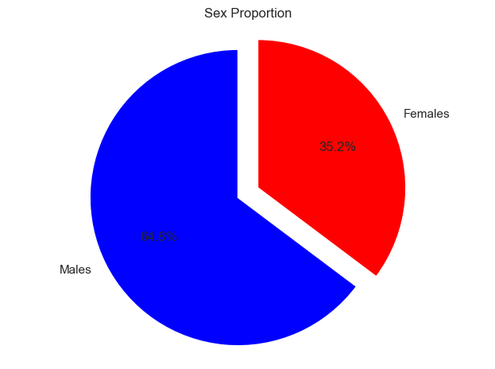

```python
males = (titanic['Sex'] == 'male').sum()
females = (titanic['Sex'] == 'female').sum()

proportions = [males, females]

plt.pie(

    proportions,

    labels = ['Males', 'Females'],

    shadow = False,

    colors = ['blue','red'],

    explode = (0.15 , 0),

    startangle = 90,

    autopct = '%1.1f%%'
    )

plt.axis('equal')

plt.title("Sex Proportion")

plt.tight_layout()
plt.show()
```

#### Step 6. Create a scatterplot with the Fare payed and the Age,

differ the plot color by gender

```
(-5.0, 85.0)
```

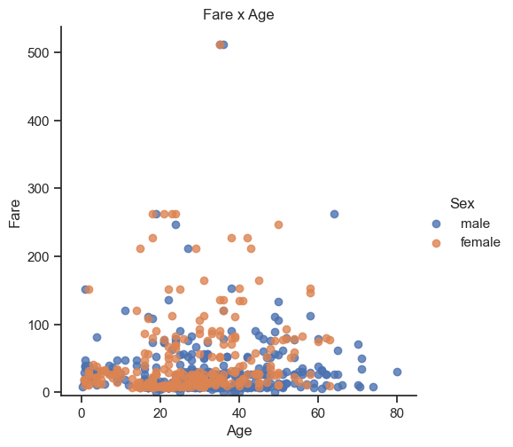

```python
lm = sns.lmplot(x = 'Age', y = 'Fare', data = titanic, hue = 'Sex', fit_reg=False)

lm.set(title = 'Fare x Age')

axes = lm.axes
axes[0,0].set_ylim(-5,)
axes[0,0].set_xlim(-5,85)
```

#### Step 7. How many people survived?

```python
titanic.Survived.sum()
```

```
342
```

#### Step 8. Create a histogram with the Fare payed

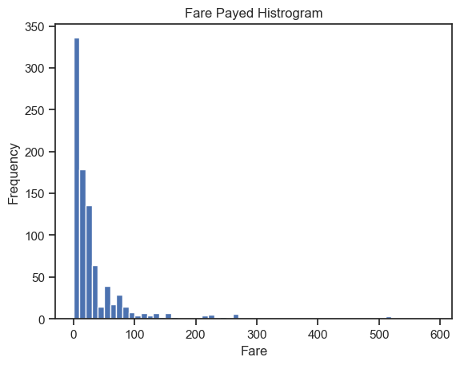

```python
df = titanic.Fare.sort_values(ascending = False)
df

binsVal = np.arange(0,600,10)
binsVal

plt.hist(df, bins = binsVal)

plt.xlabel('Fare')
plt.ylabel('Frequency')
plt.title('Fare Payed Histrogram')

plt.show()
```

#### BONUS: Create your own question and answer it.

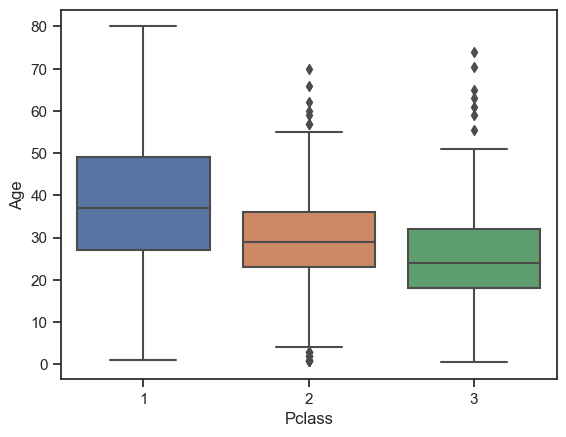

```python
sns.boxplot(x = "Pclass", y = "Age", data = titanic);
```

# Apple Stock

Introduction: We are going to use Apple's stock price.

#### Step 1. Import the necessary libraries

#### Step 2. Import the dataset from this address

#### Step 3. Assign it to a variable apple

```python
url = 'https://raw.githubusercontent.com/guipsamora/pandas_exercises/master/09_Time_Series/Apple_Stock/appl_1980_2014.csv'
apple = pd.read_csv(url)

apple.head()
```

|  | Date | Open | High | Low | Close | Volume | Adj Close |
| --- | --- | --- | --- | --- | --- | --- | --- |
| 0 | 2014-07-08 | 96.27 | 96.80 | 93.92 | 95.35 | 65130000 | 95.35 |
| 1 | 2014-07-07 | 94.14 | 95.99 | 94.10 | 95.97 | 56305400 | 95.97 |
| 2 | 2014-07-03 | 93.67 | 94.10 | 93.20 | 94.03 | 22891800 | 94.03 |
| 3 | 2014-07-02 | 93.87 | 94.06 | 93.09 | 93.48 | 28420900 | 93.48 |
| 4 | 2014-07-01 | 93.52 | 94.07 | 93.13 | 93.52 | 38170200 | 93.52 |

#### Step 4. Check out the type of the columns

```python
apple.dtypes
```

```
Date          object
Open         float64
High         float64
Low          float64
Close        float64
Volume         int64
Adj Close    float64
dtype: object
```

#### Step 5. Transform the Date column as a datetime type

```python
apple.Date = pd.to_datetime(apple.Date)

apple['Date'].head()
```

```
0   2014-07-08
1   2014-07-07
2   2014-07-03
3   2014-07-02
4   2014-07-01
Name: Date, dtype: datetime64[ns]
```

#### Step 6. Set the date as the index

```python
apple = apple.set_index('Date')

apple.head()
```

| Date | Open | High | Low | Close | Volume | Adj Close |
| --- | --- | --- | --- | --- | --- | --- |
| 2014-07-08 | 96.27 | 96.80 | 93.92 | 95.35 | 65130000 | 95.35 |
| 2014-07-07 | 94.14 | 95.99 | 94.10 | 95.97 | 56305400 | 95.97 |
| 2014-07-03 | 93.67 | 94.10 | 93.20 | 94.03 | 22891800 | 94.03 |
| 2014-07-02 | 93.87 | 94.06 | 93.09 | 93.48 | 28420900 | 93.48 |
| 2014-07-01 | 93.52 | 94.07 | 93.13 | 93.52 | 38170200 | 93.52 |

#### Step 7. Is there any duplicate dates?

```python
apple.index.is_unique
```

```
True
```

#### Step 8. Ops...it seems the index is from the most recent date.

Make the first entry the oldest date.

```python
apple.sort_index(ascending = True).head()
```

| Date | Open | High | Low | Close | Volume | Adj Close |
| --- | --- | --- | --- | --- | --- | --- |
| 1980-12-12 | 28.75 | 28.87 | 28.75 | 28.75 | 117258400 | 0.45 |
| 1980-12-15 | 27.38 | 27.38 | 27.25 | 27.25 | 43971200 | 0.42 |
| 1980-12-16 | 25.37 | 25.37 | 25.25 | 25.25 | 26432000 | 0.39 |
| 1980-12-17 | 25.87 | 26.00 | 25.87 | 25.87 | 21610400 | 0.40 |
| 1980-12-18 | 26.63 | 26.75 | 26.63 | 26.63 | 18362400 | 0.41 |

#### Step 9. Get the last business day of each month

```python
apple_month = apple.resample('BM').mean()

apple_month.head()
```

| Date | Open | High | Low | Close | Volume | Adj Close |
| --- | --- | --- | --- | --- | --- | --- |
| 1980-12-31 | 30.481538 | 30.567692 | 30.443077 | 30.443077 | 2.586252e+07 | 0.473077 |
| 1981-01-30 | 31.754762 | 31.826667 | 31.654762 | 31.654762 | 7.249867e+06 | 0.493810 |
| 1981-02-27 | 26.480000 | 26.572105 | 26.407895 | 26.407895 | 4.231832e+06 | 0.411053 |
| 1981-03-31 | 24.937727 | 25.016818 | 24.836364 | 24.836364 | 7.962691e+06 | 0.387727 |
| 1981-04-30 | 27.286667 | 27.368095 | 27.227143 | 27.227143 | 6.392000e+06 | 0.423333 |

#### Step 10. What is the difference in days between the first day

and the oldest

```python
(apple.index.max() - apple.index.min()).days
```

```
12261
```

#### Step 11. How many months in the data we have?

```python
apple_months = apple.resample('BM').mean()

len(apple_months.index)
```

```
404
```

#### Step 12. Plot the 'Adj Close' value. Set the size of the figure to

13.5 x 9 inches

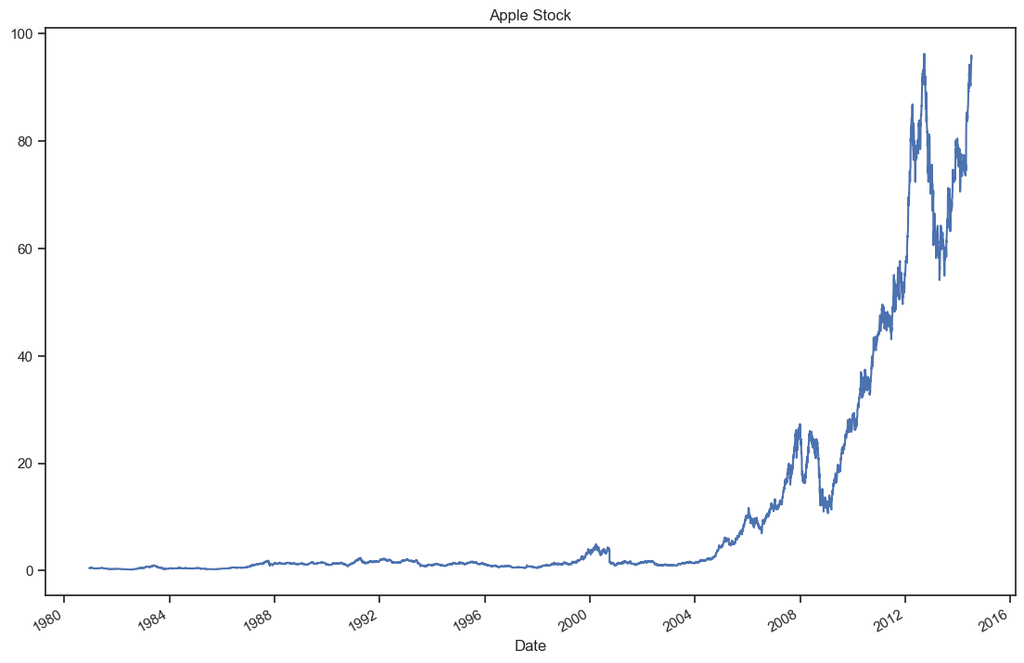

```python
appl_open = apple['Adj Close'].plot(title = "Apple Stock")

fig = appl_open.get_figure()
fig.set_size_inches(13.5, 9)
```

#### BONUS: Create your own question and answer it.

```python
vol = apple['Volume']
total = apple['Adj Close']
```

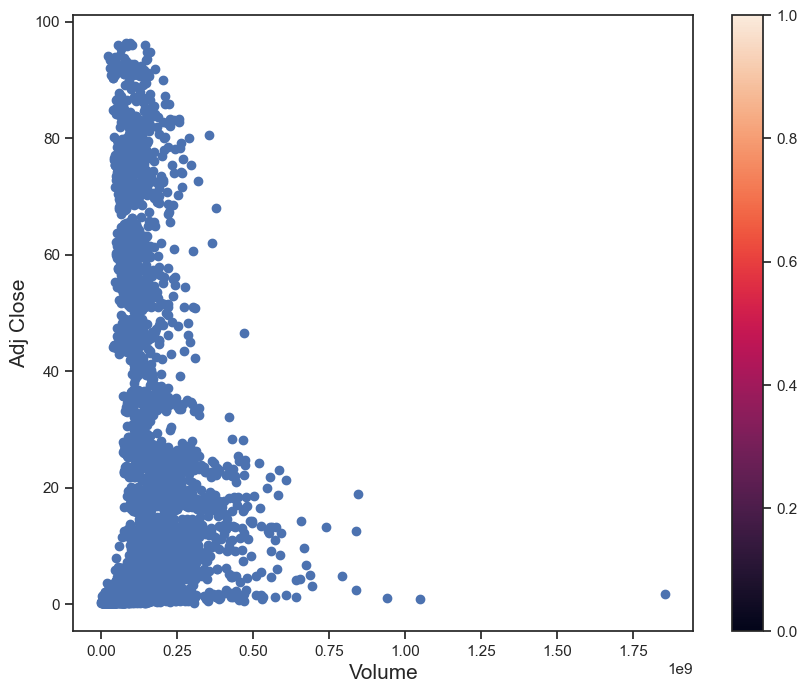

```python
plt.figure(figsize=(10,8))
plt.scatter(vol, total)
plt.xlabel('Volume', fontsize=15)
plt.ylabel('Adj Close', fontsize=15)
plt.colorbar()
plt.show()
```

# Investor - Flow of Funds - US

Introduction: Special thanks to: https://github.com/rgrp for sharing the dataset.

#### Step 1. Import the necessary libraries

#### Step 2. Import the dataset from this address.

```python
url = 'https://raw.githubusercontent.com/datasets/investor-flow-of-funds-us/master/data/weekly.csv'
df = pd.read_csv(url)
df.head()
```

|  | Date | Total Equity | Domestic Equity | World Equity | Hybrid | Total Bond | Taxable Bond | Municipal Bond | Total |
| --- | --- | --- | --- | --- | --- | --- | --- | --- | --- |
| 0 | 2012-12-05 | -7426 | -6060 | -1367 | -74 | 5317 | 4210 | 1107 | -2183 |
| 1 | 2012-12-12 | -8783 | -7520 | -1263 | 123 | 1818 | 1598 | 219 | -6842 |
| 2 | 2012-12-19 | -5496 | -5470 | -26 | -73 | 103 | 3472 | -3369 | -5466 |
| 3 | 2012-12-26 | -4451 | -4076 | -375 | 550 | 2610 | 3333 | -722 | -1291 |
| 4 | 2013-01-02 | -11156 | -9622 | -1533 | -158 | 2383 | 2103 | 280 | -8931 |

#### Step 4. Set the column Date as the index.

```python
df = df.set_index('Date')
df.head()
```

| Date | Total Equity | Domestic Equity | World Equity | Hybrid | Total Bond | Taxable Bond | Municipal Bond | Total |
| --- | --- | --- | --- | --- | --- | --- | --- | --- |
| 2012-12-05 | -7426 | -6060 | -1367 | -74 | 5317 | 4210 | 1107 | -2183 |
| 2012-12-12 | -8783 | -7520 | -1263 | 123 | 1818 | 1598 | 219 | -6842 |
| 2012-12-19 | -5496 | -5470 | -26 | -73 | 103 | 3472 | -3369 | -5466 |
| 2012-12-26 | -4451 | -4076 | -375 | 550 | 2610 | 3333 | -722 | -1291 |
| 2013-01-02 | -11156 | -9622 | -1533 | -158 | 2383 | 2103 | 280 | -8931 |

#### Step 5. What is the type of the index?

```python
df.index
```

```
Index(['2012-12-05', '2012-12-12', '2012-12-19', '2012-12-26', '2013-01-02',
       '2013-01-09', '2014-04-02', '2014-04-09', '2014-04-16', '2014-04-23',
       '2014-04-30', '2014-05-07', '2014-05-14', '2014-05-21', '2014-05-28',
       '2014-06-04', '2014-06-11', '2014-06-18', '2014-06-25', '2014-07-02',
       '2014-07-09', '2014-07-30', '2014-08-06', '2014-08-13', '2014-08-20',
       '2014-08-27', '2014-09-03', '2014-09-10', '2014-11-05', '2014-11-12',
       '2014-11-19', '2014-11-25', '2015-01-07', '2015-01-14', '2015-01-21',
       '2015-01-28', '2015-02-04', '2015-02-11', '2015-03-04', '2015-03-11',
       '2015-03-18', '2015-03-25', '2015-04-01', '2015-04-08'],
      dtype='object', name='Date')
```

#### Step 6. Set the index to a DatetimeIndex type

```python
df.index = pd.to_datetime(df.index)
type(df.index)
```

```
pandas.core.indexes.datetimes.DatetimeIndex
```

#### Step 7. Change the frequency to monthly, sum the values and

assign it to monthly

```python
monthly = df.resample('M').sum()
monthly
```

| Date | Total Equity | Domestic Equity | World Equity | Hybrid | Total Bond | Taxable Bond | Municipal Bond | Total |
| --- | --- | --- | --- | --- | --- | --- | --- | --- |
| 2012-12-31 | -26156 | -23126 | -3031 | 526 | 9848 | 12613 | -2765 | -15782 |
| 2013-01-31 | 3661 | -1627 | 5288 | 2730 | 12149 | 9414 | 2735 | 18540 |
| 2013-02-28 | 0 | 0 | 0 | 0 | 0 | 0 | 0 | 0 |
| 2013-03-31 | 0 | 0 | 0 | 0 | 0 | 0 | 0 | 0 |
| 2013-04-30 | 0 | 0 | 0 | 0 | 0 | 0 | 0 | 0 |
| 2013-05-31 | 0 | 0 | 0 | 0 | 0 | 0 | 0 | 0 |
| 2013-06-30 | 0 | 0 | 0 | 0 | 0 | 0 | 0 | 0 |
| 2013-07-31 | 0 | 0 | 0 | 0 | 0 | 0 | 0 | 0 |
| 2013-08-31 | 0 | 0 | 0 | 0 | 0 | 0 | 0 | 0 |
| 2013-09-30 | 0 | 0 | 0 | 0 | 0 | 0 | 0 | 0 |
| 2013-10-31 | 0 | 0 | 0 | 0 | 0 | 0 | 0 | 0 |
| 2013-11-30 | 0 | 0 | 0 | 0 | 0 | 0 | 0 | 0 |
| 2013-12-31 | 0 | 0 | 0 | 0 | 0 | 0 | 0 | 0 |
| 2014-01-31 | 0 | 0 | 0 | 0 | 0 | 0 | 0 | 0 |
| 2014-02-28 | 0 | 0 | 0 | 0 | 0 | 0 | 0 | 0 |
| 2014-03-31 | 0 | 0 | 0 | 0 | 0 | 0 | 0 | 0 |
| 2014-04-30 | 10842 | 1048 | 9794 | 4931 | 8493 | 7193 | 1300 | 24267 |
| 2014-05-31 | -2203 | -8720 | 6518 | 3172 | 13767 | 10192 | 3576 | 14736 |
| 2014-06-30 | 2319 | -6546 | 8865 | 4588 | 9715 | 7551 | 2163 | 16621 |
| 2014-07-31 | -7051 | -11128 | 4078 | 2666 | 7506 | 7026 | 481 | 3122 |
| 2014-08-31 | 1943 | -5508 | 7452 | 1885 | 1897 | -1013 | 2910 | 5723 |
| 2014-09-30 | -2767 | -6596 | 3829 | 1599 | 3984 | 2479 | 1504 | 2816 |
| 2014-10-31 | 0 | 0 | 0 | 0 | 0 | 0 | 0 | 0 |
| 2014-11-30 | -2753 | -7239 | 4485 | 729 | 14528 | 11566 | 2962 | 12502 |
| 2014-12-31 | 0 | 0 | 0 | 0 | 0 | 0 | 0 | 0 |
| 2015-01-31 | 3471 | -1164 | 4635 | 1729 | 7368 | 2762 | 4606 | 12569 |
| 2015-02-28 | 5508 | 3509 | 1999 | 1752 | 9099 | 7443 | 1656 | 16359 |
| 2015-03-31 | 5691 | -8176 | 13867 | 2829 | 9138 | 7267 | 1870 | 17657 |
| 2015-04-30 | 379 | -4628 | 5007 | 970 | 423 | 514 | -91 | 1772 |

```python
monthly = monthly.dropna()
monthly
```

| Date | Total Equity | Domestic Equity | World Equity | Hybrid | Total Bond | Taxable Bond | Municipal Bond | Total |
| --- | --- | --- | --- | --- | --- | --- | --- | --- |
| 2012-12-31 | -26156 | -23126 | -3031 | 526 | 9848 | 12613 | -2765 | -15782 |
| 2013-01-31 | 3661 | -1627 | 5288 | 2730 | 12149 | 9414 | 2735 | 18540 |
| 2013-02-28 | 0 | 0 | 0 | 0 | 0 | 0 | 0 | 0 |
| 2013-03-31 | 0 | 0 | 0 | 0 | 0 | 0 | 0 | 0 |
| 2013-04-30 | 0 | 0 | 0 | 0 | 0 | 0 | 0 | 0 |
| 2013-05-31 | 0 | 0 | 0 | 0 | 0 | 0 | 0 | 0 |
| 2013-06-30 | 0 | 0 | 0 | 0 | 0 | 0 | 0 | 0 |
| 2013-07-31 | 0 | 0 | 0 | 0 | 0 | 0 | 0 | 0 |
| 2013-08-31 | 0 | 0 | 0 | 0 | 0 | 0 | 0 | 0 |
| 2013-09-30 | 0 | 0 | 0 | 0 | 0 | 0 | 0 | 0 |
| 2013-10-31 | 0 | 0 | 0 | 0 | 0 | 0 | 0 | 0 |
| 2013-11-30 | 0 | 0 | 0 | 0 | 0 | 0 | 0 | 0 |
| 2013-12-31 | 0 | 0 | 0 | 0 | 0 | 0 | 0 | 0 |
| 2014-01-31 | 0 | 0 | 0 | 0 | 0 | 0 | 0 | 0 |
| 2014-02-28 | 0 | 0 | 0 | 0 | 0 | 0 | 0 | 0 |
| 2014-03-31 | 0 | 0 | 0 | 0 | 0 | 0 | 0 | 0 |
| 2014-04-30 | 10842 | 1048 | 9794 | 4931 | 8493 | 7193 | 1300 | 24267 |
| 2014-05-31 | -2203 | -8720 | 6518 | 3172 | 13767 | 10192 | 3576 | 14736 |
| 2014-06-30 | 2319 | -6546 | 8865 | 4588 | 9715 | 7551 | 2163 | 16621 |
| 2014-07-31 | -7051 | -11128 | 4078 | 2666 | 7506 | 7026 | 481 | 3122 |
| 2014-08-31 | 1943 | -5508 | 7452 | 1885 | 1897 | -1013 | 2910 | 5723 |
| 2014-09-30 | -2767 | -6596 | 3829 | 1599 | 3984 | 2479 | 1504 | 2816 |
| 2014-10-31 | 0 | 0 | 0 | 0 | 0 | 0 | 0 | 0 |
| 2014-11-30 | -2753 | -7239 | 4485 | 729 | 14528 | 11566 | 2962 | 12502 |
| 2014-12-31 | 0 | 0 | 0 | 0 | 0 | 0 | 0 | 0 |
| 2015-01-31 | 3471 | -1164 | 4635 | 1729 | 7368 | 2762 | 4606 | 12569 |
| 2015-02-28 | 5508 | 3509 | 1999 | 1752 | 9099 | 7443 | 1656 | 16359 |
| 2015-03-31 | 5691 | -8176 | 13867 | 2829 | 9138 | 7267 | 1870 | 17657 |
| 2015-04-30 | 379 | -4628 | 5007 | 970 | 423 | 514 | -91 | 1772 |

#### Step 9. Good, now we have the monthly data. Now change

the frequency to year

```python
year = monthly.resample('AS-JAN').sum()
year
```

| Date | Total Equity | Domestic Equity | World Equity | Hybrid | Total Bond | Taxable Bond | Municipal Bond | Total |
| --- | --- | --- | --- | --- | --- | --- | --- | --- |
| 2012-01-01 | -26156 | -23126 | -3031 | 526 | 9848 | 12613 | -2765 | -15782 |
| 2013-01-01 | 3661 | -1627 | 5288 | 2730 | 12149 | 9414 | 2735 | 18540 |
| 2014-01-01 | 330 | -44689 | 45021 | 19570 | 59890 | 44994 | 14896 | 79787 |
| 2015-01-01 | 15049 | -10459 | 25508 | 7280 | 26028 | 17986 | 8041 | 48357 |

#### BONUS: Create your own question and answer it.

```python
df.shape[0]
```

```
44
```

# Iris

Introduction: This exercise may seem a little bit strange, but keep doing it.

### Step 1. Import the necessary libraries

### Step 2. Import the dataset from this address.

### Step 3. Assign it to a variable called iris

```python
url = 'https://archive.ics.uci.edu/ml/machine-learning-databases/iris/iris.data'
iris = pd.read_csv(url)

iris.head()
```

|  | 5.1 | 3.5 | 1.4 | 0.2 | Iris-setosa |
| --- | --- | --- | --- | --- | --- |
| 0 | 4.9 | 3.0 | 1.4 | 0.2 | Iris-setosa |
| 1 | 4.7 | 3.2 | 1.3 | 0.2 | Iris-setosa |
| 2 | 4.6 | 3.1 | 1.5 | 0.2 | Iris-setosa |
| 3 | 5.0 | 3.6 | 1.4 | 0.2 | Iris-setosa |
| 4 | 5.4 | 3.9 | 1.7 | 0.4 | Iris-setosa |

### Step 4. Create columns for the dataset

#### 1. sepal_length (in cm)

#### 2. sepal_width (in cm)

#### 3. petal_length (in cm)

#### 4. petal_width (in cm)

#### 5. class

```python
iris.columns = ['sepal_length','sepal_width', 'petal_length', 'petal_width', 'class']
iris.head()
```

|  | sepal_length | sepal_width | petal_length | petal_width | class |
| --- | --- | --- | --- | --- | --- |
| 0 | 4.9 | 3.0 | 1.4 | 0.2 | Iris-setosa |
| 1 | 4.7 | 3.2 | 1.3 | 0.2 | Iris-setosa |
| 2 | 4.6 | 3.1 | 1.5 | 0.2 | Iris-setosa |
| 3 | 5.0 | 3.6 | 1.4 | 0.2 | Iris-setosa |
| 4 | 5.4 | 3.9 | 1.7 | 0.4 | Iris-setosa |

#### Step 5. Is there any missing value in the dataframe?

```python
pd.isnull(iris).sum()
```

```
sepal_length    0
sepal_width     0
petal_length    0
petal_width     0
class           0
dtype: int64
```

#### Step 6. Lets set the values of the rows 10 to 29 of the column

'petal_length' to NaN

```python
iris.iloc[10:30,2:3] = np.nan
iris.head(20)
```

|  | sepal_length | sepal_width | petal_length | petal_width | class |
| --- | --- | --- | --- | --- | --- |
| 0 | 4.9 | 3.0 | 1.4 | 0.2 | Iris-setosa |
| 1 | 4.7 | 3.2 | 1.3 | 0.2 | Iris-setosa |
| 2 | 4.6 | 3.1 | 1.5 | 0.2 | Iris-setosa |
| 3 | 5.0 | 3.6 | 1.4 | 0.2 | Iris-setosa |
| 4 | 5.4 | 3.9 | 1.7 | 0.4 | Iris-setosa |
| 5 | 4.6 | 3.4 | 1.4 | 0.3 | Iris-setosa |
| 6 | 5.0 | 3.4 | 1.5 | 0.2 | Iris-setosa |
| 7 | 4.4 | 2.9 | 1.4 | 0.2 | Iris-setosa |
| 8 | 4.9 | 3.1 | 1.5 | 0.1 | Iris-setosa |
| 9 | 5.4 | 3.7 | 1.5 | 0.2 | Iris-setosa |
| 10 | 4.8 | 3.4 | NaN | 0.2 | Iris-setosa |
| 11 | 4.8 | 3.0 | NaN | 0.1 | Iris-setosa |
| 12 | 4.3 | 3.0 | NaN | 0.1 | Iris-setosa |
| 13 | 5.8 | 4.0 | NaN | 0.2 | Iris-setosa |
| 14 | 5.7 | 4.4 | NaN | 0.4 | Iris-setosa |
| 15 | 5.4 | 3.9 | NaN | 0.4 | Iris-setosa |
| 16 | 5.1 | 3.5 | NaN | 0.3 | Iris-setosa |
| 17 | 5.7 | 3.8 | NaN | 0.3 | Iris-setosa |
| 18 | 5.1 | 3.8 | NaN | 0.3 | Iris-setosa |
| 19 | 5.4 | 3.4 | NaN | 0.2 | Iris-setosa |

#### Step 7. Good, now lets substitute the NaN values to 1.0

```python
iris.petal_length.fillna(1, inplace = True)
iris
```

|  | sepal_length | sepal_width | petal_length | petal_width | class |
| --- | --- | --- | --- | --- | --- |
| 0 | 4.9 | 3.0 | 1.4 | 0.2 | Iris-setosa |
| 1 | 4.7 | 3.2 | 1.3 | 0.2 | Iris-setosa |
| 2 | 4.6 | 3.1 | 1.5 | 0.2 | Iris-setosa |
| 3 | 5.0 | 3.6 | 1.4 | 0.2 | Iris-setosa |
| 4 | 5.4 | 3.9 | 1.7 | 0.4 | Iris-setosa |
| ... | ... | ... | ... | ... | ... |
| 144 | 6.7 | 3.0 | 5.2 | 2.3 | Iris-virginica |
| 145 | 6.3 | 2.5 | 5.0 | 1.9 | Iris-virginica |
| 146 | 6.5 | 3.0 | 5.2 | 2.0 | Iris-virginica |
| 147 | 6.2 | 3.4 | 5.4 | 2.3 | Iris-virginica |
| 148 | 5.9 | 3.0 | 5.1 | 1.8 | Iris-virginica |

149 rows × 5 columns

#### Step 8. Now let's delete the column class

```python
del iris['class']
iris.head()
```

|  | sepal_length | sepal_width | petal_length | petal_width |
| --- | --- | --- | --- | --- |
| 0 | 4.9 | 3.0 | 1.4 | 0.2 |
| 1 | 4.7 | 3.2 | 1.3 | 0.2 |
| 2 | 4.6 | 3.1 | 1.5 | 0.2 |
| 3 | 5.0 | 3.6 | 1.4 | 0.2 |
| 4 | 5.4 | 3.9 | 1.7 | 0.4 |

#### Step 9. Set the first 3 rows as NaN

```python
iris.iloc[0:3 ,:] = np.nan
iris.head()
```

|  | sepal_length | sepal_width | petal_length | petal_width |
| --- | --- | --- | --- | --- |
| 0 | NaN | NaN | NaN | NaN |
| 1 | NaN | NaN | NaN | NaN |
| 2 | NaN | NaN | NaN | NaN |
| 3 | 5.0 | 3.6 | 1.4 | 0.2 |
| 4 | 5.4 | 3.9 | 1.7 | 0.4 |

#### Step 10. Delete the rows that have NaN

```python
iris = iris.dropna(how='any')
iris.head()
```

|  | sepal_length | sepal_width | petal_length | petal_width |
| --- | --- | --- | --- | --- |
| 3 | 5.0 | 3.6 | 1.4 | 0.2 |
| 4 | 5.4 | 3.9 | 1.7 | 0.4 |
| 5 | 4.6 | 3.4 | 1.4 | 0.3 |
| 6 | 5.0 | 3.4 | 1.5 | 0.2 |
| 7 | 4.4 | 2.9 | 1.4 | 0.2 |

#### Step 11. Reset the index so it begins with 0 again

```python
iris = iris.reset_index(drop = True)
iris.head()
```

|  | sepal_length | sepal_width | petal_length | petal_width |
| --- | --- | --- | --- | --- |
| 0 | 5.0 | 3.6 | 1.4 | 0.2 |
| 1 | 5.4 | 3.9 | 1.7 | 0.4 |
| 2 | 4.6 | 3.4 | 1.4 | 0.3 |
| 3 | 5.0 | 3.4 | 1.5 | 0.2 |
| 4 | 4.4 | 2.9 | 1.4 | 0.2 |

#### BONUS: Create your own question and answer it

```python
iris.describe()
```

|  | sepal_length | sepal_width | petal_length | petal_width |
| --- | --- | --- | --- | --- |
| count | 146.000000 | 146.000000 | 146.000000 | 146.000000 |
| mean | 5.871233 | 3.050000 | 3.756164 | 1.226027 |
| std | 0.821098 | 0.437745 | 1.838214 | 0.755125 |
| min | 4.300000 | 2.000000 | 1.000000 | 0.100000 |
| 25% | 5.125000 | 2.800000 | 1.500000 | 0.325000 |
| 50% | 5.800000 | 3.000000 | 4.400000 | 1.300000 |
| 75% | 6.400000 | 3.300000 | 5.100000 | 1.800000 |
| max | 7.900000 | 4.400000 | 6.900000 | 2.500000 |

# Wine

Introduction: This exercise is a adaptation from the UCI Wine dataset. The only pupose is to practice deleting data with pandas.

#### Step 1. Import the necessary libraries

#### Step 2. Import the dataset from this address.

#### Step 3. Assign it to a variable called wine

```python
url = 'https://archive.ics.uci.edu/ml/machine-learning-databases/wine/wine.data'
wine = pd.read_csv(url)

wine.head()
```

|  | 1 | 14.23 | 1.71 | 2.43 | 15.6 | 127 | 2.8 | 3.06 | .28 | 2.29 | 5.64 | 1.04 | 3.92 | 1065 |
| --- | --- | --- | --- | --- | --- | --- | --- | --- | --- | --- | --- | --- | --- | --- |
| 0 | 1 | 13.20 | 1.78 | 2.14 | 11.2 | 100 | 2.65 | 2.76 | 0.26 | 1.28 | 4.38 | 1.05 | 3.40 | 1050 |
| 1 | 1 | 13.16 | 2.36 | 2.67 | 18.6 | 101 | 2.80 | 3.24 | 0.30 | 2.81 | 5.68 | 1.03 | 3.17 | 1185 |
| 2 | 1 | 14.37 | 1.95 | 2.50 | 16.8 | 113 | 3.85 | 3.49 | 0.24 | 2.18 | 7.80 | 0.86 | 3.45 | 1480 |
| 3 | 1 | 13.24 | 2.59 | 2.87 | 21.0 | 118 | 2.80 | 2.69 | 0.39 | 1.82 | 4.32 | 1.04 | 2.93 | 735 |
| 4 | 1 | 14.20 | 1.76 | 2.45 | 15.2 | 112 | 3.27 | 3.39 | 0.34 | 1.97 | 6.75 | 1.05 | 2.85 | 1450 |

```python
wine = wine.drop(wine.columns[[0,3,6,8,11,12,13]], axis = 1)

wine.head()
```

|  | 14.23 | 1.71 | 15.6 | 127 | 3.06 | 2.29 | 5.64 |
| --- | --- | --- | --- | --- | --- | --- | --- |
| 0 | 13.20 | 1.78 | 11.2 | 100 | 2.76 | 1.28 | 4.38 |
| 1 | 13.16 | 2.36 | 18.6 | 101 | 3.24 | 2.81 | 5.68 |
| 2 | 14.37 | 1.95 | 16.8 | 113 | 3.49 | 2.18 | 7.80 |
| 3 | 13.24 | 2.59 | 21.0 | 118 | 2.69 | 1.82 | 4.32 |
| 4 | 14.20 | 1.76 | 15.2 | 112 | 3.39 | 1.97 | 6.75 |

#### Step 5. Assign the columns as below:

```python
wine.columns = ['alcohol', 'malic_acid', 'alcalinity_of_ash', 'magnesium', 'flavanoids', 'proanthocyanins', 'hue']
wine.head()
```

|  | alcohol | malic_acid | alcalinity_of_ash | magnesium | flavanoids | proanthocyanins | hue |
| --- | --- | --- | --- | --- | --- | --- | --- |
| 0 | 13.20 | 1.78 | 11.2 | 100 | 2.76 | 1.28 | 4.38 |
| 1 | 13.16 | 2.36 | 18.6 | 101 | 3.24 | 2.81 | 5.68 |
| 2 | 14.37 | 1.95 | 16.8 | 113 | 3.49 | 2.18 | 7.80 |
| 3 | 13.24 | 2.59 | 21.0 | 118 | 2.69 | 1.82 | 4.32 |
| 4 | 14.20 | 1.76 | 15.2 | 112 | 3.39 | 1.97 | 6.75 |

#### Step 6. Set the values of the first 3 rows from alcohol as NaN

```python
wine.iloc[0:3, 0] = np.nan
wine.head()
```

|  | alcohol | malic_acid | alcalinity_of_ash | magnesium | flavanoids | proanthocyanins | hue |
| --- | --- | --- | --- | --- | --- | --- | --- |
| 0 | NaN | 1.78 | 11.2 | 100 | 2.76 | 1.28 | 4.38 |
| 1 | NaN | 2.36 | 18.6 | 101 | 3.24 | 2.81 | 5.68 |
| 2 | NaN | 1.95 | 16.8 | 113 | 3.49 | 2.18 | 7.80 |
| 3 | 13.24 | 2.59 | 21.0 | 118 | 2.69 | 1.82 | 4.32 |
| 4 | 14.20 | 1.76 | 15.2 | 112 | 3.39 | 1.97 | 6.75 |

#### Step 7. Now set the value of the rows 3 and 4 of magnesium

as NaN

```python
wine.iloc[2:4, 3] = np.nan
wine.head()
```

|  | alcohol | malic_acid | alcalinity_of_ash | magnesium | flavanoids | proanthocyanins | hue |
| --- | --- | --- | --- | --- | --- | --- | --- |
| 0 | NaN | 1.78 | 11.2 | 100.0 | 2.76 | 1.28 | 4.38 |
| 1 | NaN | 2.36 | 18.6 | 101.0 | 3.24 | 2.81 | 5.68 |
| 2 | NaN | 1.95 | 16.8 | NaN | 3.49 | 2.18 | 7.80 |
| 3 | 13.24 | 2.59 | 21.0 | NaN | 2.69 | 1.82 | 4.32 |
| 4 | 14.20 | 1.76 | 15.2 | 112.0 | 3.39 | 1.97 | 6.75 |

#### Step 8. Fill the value of NaN with the number 10 in alcohol

and 100 in magnesium

```python
wine.alcohol.fillna(10, inplace = True)

wine.magnesium.fillna(100, inplace = True)

wine.head()
```

|  | alcohol | malic_acid | alcalinity_of_ash | magnesium | flavanoids | proanthocyanins | hue |
| --- | --- | --- | --- | --- | --- | --- | --- |
| 0 | 10.00 | 1.78 | 11.2 | 100.0 | 2.76 | 1.28 | 4.38 |
| 1 | 10.00 | 2.36 | 18.6 | 101.0 | 3.24 | 2.81 | 5.68 |
| 2 | 10.00 | 1.95 | 16.8 | 100.0 | 3.49 | 2.18 | 7.80 |
| 3 | 13.24 | 2.59 | 21.0 | 100.0 | 2.69 | 1.82 | 4.32 |
| 4 | 14.20 | 1.76 | 15.2 | 112.0 | 3.39 | 1.97 | 6.75 |

#### Step 9. Count the number of missing values

```python
wine.isnull().sum()
```

```
alcohol              0
malic_acid           0
alcalinity_of_ash    0
magnesium            0
flavanoids           0
proanthocyanins      0
hue                  0
dtype: int64
```

#### Step 10. Create an array of 10 random numbers up until 10

```python
random = np.random.randint(10, size = 10)
random
```

```
array([3, 1, 4, 0, 1, 7, 5, 2, 9, 1])
```

#### Step 11. Use random numbers you generated as an index and

assign NaN value to each of cell.

```python
wine.alcohol[random] = np.nan
wine.head(10)
```

|  | alcohol | malic_acid | alcalinity_of_ash | magnesium | flavanoids | proanthocyanins | hue |
| --- | --- | --- | --- | --- | --- | --- | --- |
| 0 | NaN | 1.78 | 11.2 | 100.0 | 2.76 | 1.28 | 4.38 |
| 1 | NaN | 2.36 | 18.6 | 101.0 | 3.24 | 2.81 | 5.68 |
| 2 | NaN | 1.95 | 16.8 | 100.0 | 3.49 | 2.18 | 7.80 |
| 3 | NaN | 2.59 | 21.0 | 100.0 | 2.69 | 1.82 | 4.32 |
| 4 | NaN | 1.76 | 15.2 | 112.0 | 3.39 | 1.97 | 6.75 |
| 5 | NaN | 1.87 | 14.6 | 96.0 | 2.52 | 1.98 | 5.25 |
| 6 | 14.06 | 2.15 | 17.6 | 121.0 | 2.51 | 1.25 | 5.05 |
| 7 | NaN | 1.64 | 14.0 | 97.0 | 2.98 | 1.98 | 5.20 |
| 8 | 13.86 | 1.35 | 16.0 | 98.0 | 3.15 | 1.85 | 7.22 |
| 9 | NaN | 2.16 | 18.0 | 105.0 | 3.32 | 2.38 | 5.75 |

#### Step 12. How many missing values do we have?

```python
wine.isnull().sum()
```

```
alcohol              8
malic_acid           0
alcalinity_of_ash    0
magnesium            0
flavanoids           0
proanthocyanins      0
hue                  0
dtype: int64
```

#### Step 13. Delete the rows that contain missing values

```python
wine = wine.dropna(axis = 0, how = "any")
wine.head()
```

|  | alcohol | malic_acid | alcalinity_of_ash | magnesium | flavanoids | proanthocyanins | hue |
| --- | --- | --- | --- | --- | --- | --- | --- |
| 6 | 14.06 | 2.15 | 17.6 | 121.0 | 2.51 | 1.25 | 5.05 |
| 8 | 13.86 | 1.35 | 16.0 | 98.0 | 3.15 | 1.85 | 7.22 |
| 10 | 14.12 | 1.48 | 16.8 | 95.0 | 2.43 | 1.57 | 5.00 |
| 11 | 13.75 | 1.73 | 16.0 | 89.0 | 2.76 | 1.81 | 5.60 |
| 12 | 14.75 | 1.73 | 11.4 | 91.0 | 3.69 | 2.81 | 5.40 |

#### Step 14. Print only the non-null values in alcohol

```python
mask = wine.alcohol.notnull()
mask
```

```
6      True
8      True
10     True
11     True
12     True
       ...
172    True
173    True
174    True
175    True
176    True
Name: alcohol, Length: 169, dtype: bool
```

#### Step 15. Reset the index, so it starts with 0 again

```python
wine = wine.reset_index(drop = True)
wine.head()
```

|  | alcohol | malic_acid | alcalinity_of_ash | magnesium | flavanoids | proanthocyanins | hue |
| --- | --- | --- | --- | --- | --- | --- | --- |
| 0 | 14.06 | 2.15 | 17.6 | 121.0 | 2.51 | 1.25 | 5.05 |
| 1 | 13.86 | 1.35 | 16.0 | 98.0 | 3.15 | 1.85 | 7.22 |
| 2 | 14.12 | 1.48 | 16.8 | 95.0 | 2.43 | 1.57 | 5.00 |
| 3 | 13.75 | 1.73 | 16.0 | 89.0 | 2.76 | 1.81 | 5.60 |
| 4 | 14.75 | 1.73 | 11.4 | 91.0 | 3.69 | 2.81 | 5.40 |

### BONUS: Create your own question and answer it.

```python
wine.describe()
```

|  | alcohol | malic_acid | alcalinity_of_ash | magnesium | flavanoids | proanthocyanins | hue |
| --- | --- | --- | --- | --- | --- | --- | --- |
| count | 169.000000 | 169.000000 | 169.000000 | 169.000000 | 169.000000 | 169.000000 | 169.000000 |
| mean | 12.949053 | 2.355325 | 19.675148 | 99.319527 | 1.974911 | 1.565030 | 5.027041 |
| std | 0.789709 | 1.141366 | 3.272719 | 14.355757 | 0.993437 | 0.568681 | 2.363498 |
| min | 11.030000 | 0.740000 | 10.600000 | 70.000000 | 0.340000 | 0.410000 | 1.280000 |
| 25% | 12.330000 | 1.570000 | 17.500000 | 88.000000 | 1.090000 | 1.220000 | 3.080000 |
| 50% | 12.960000 | 1.860000 | 19.500000 | 97.000000 | 2.030000 | 1.530000 | 4.600000 |
| 75% | 13.620000 | 3.170000 | 21.500000 | 107.000000 | 2.780000 | 1.870000 | 6.200000 |
| max | 14.750000 | 5.800000 | 30.000000 | 162.000000 | 5.080000 | 3.580000 | 13.000000 |

# Pokemon

Introduction: This time you will create the data.

### Step 1. Import the necessary libraries

### Step 2. Create a data dictionary that looks like the DataFrame

below

```python
raw_data = {"evolution": ['Ivysaur','Charmeleon','Wartortle','Metapod'],
            "hp": [45, 39, 44, 45],
            "name": ['Bulbasaur', 'Charmander','Squirtle','Caterpie'],
            "pokedex": ['yes', 'no','yes','no'],
             "type": ['grass', 'fire', 'water', 'bug']
            }
```

### Step 3. Assign it to a variable called pokemon

```python
pokemon = pd.DataFrame(raw_data)
pokemon
```

|  | evolution | hp | name | pokedex | type |
| --- | --- | --- | --- | --- | --- |
| 0 | Ivysaur | 45 | Bulbasaur | yes | grass |
| 1 | Charmeleon | 39 | Charmander | no | fire |
| 2 | Wartortle | 44 | Squirtle | yes | water |
| 3 | Metapod | 45 | Caterpie | no | bug |

### Step 4. Ops...it seems the DataFrame columns are in

alphabetical order. Place the order of the columns as name, type, hp, evolution, pokedex

```python
pokemon1 = pd.DataFrame.from_dict(raw_data)
pokemon1 = pokemon1[["name", "type", "hp", "evolution", "pokedex"]]
pokemon1
```

|  | name | type | hp | evolution | pokedex |
| --- | --- | --- | --- | --- | --- |
| 0 | Bulbasaur | grass | 45 | Ivysaur | yes |
| 1 | Charmander | fire | 39 | Charmeleon | no |
| 2 | Squirtle | water | 44 | Wartortle | yes |
| 3 | Caterpie | bug | 45 | Metapod | no |

#### Step 5. Add another column called place, and insert what you

have in mind.

```python
place = ["Hills","Volcano","Lakes","park"]
pokemon1["Place"] = place
pokemon1
```

|  | name | type | hp | evolution | pokedex | Place |
| --- | --- | --- | --- | --- | --- | --- |
| 0 | Bulbasaur | grass | 45 | Ivysaur | yes | Hills |
| 1 | Charmander | fire | 39 | Charmeleon | no | Volcano |
| 2 | Squirtle | water | 44 | Wartortle | yes | Lakes |
| 3 | Caterpie | bug | 45 | Metapod | no | park |

#### Step 6. Present the type of each column

```python
pokemon1.dtypes
```

```
name         object
type         object
hp            int64
evolution    object
pokedex      object
Place        object
dtype: object
```

#### BONUS: Create your own question and answer it.

#### Place the order of the columns as pokedex , name, evolution, type,hp

```python
pokemon1 = pd.DataFrame.from_dict(raw_data)
pokemon1 = pokemon1[["pokedex", "name", "evolution", "type", "hp" ]]
pokemon1
```

|  | pokedex | name | evolution | type | hp |
| --- | --- | --- | --- | --- | --- |
| 0 | yes | Bulbasaur | Ivysaur | grass | 45 |
| 1 | no | Charmander | Charmeleon | fire | 39 |
| 2 | yes | Squirtle | Wartortle | water | 44 |
| 3 | no | Caterpie | Metapod | bug | 45 |